# Perceptual VSUPs

## Setup

```r
library(tidyverse)
library(magrittr)
library(rstan)
library(brms)
library(tidybayes)
library(ggstance)
library(modelr)
library(patchwork)
library(tidyr)
library(ggstance)
library(cowplot)

options(mc.cores = parallel::detectCores())
rstan_options(auto_write = TRUE)
theme_set(theme_tidybayes())
```

### Load data

Load the polling data…

```r
polls = read_csv("examples/polling.csv",
  col_types = cols(
    State = col_character(),
    Date = col_character(),
    `Hillary Clinton` = col_number(),
    `Donald Trump` = col_number(),
    `Gary Johnson` = col_number(),
    `Jill Stein` = col_number(),
    `Evan McMullin` = col_number(),
    `Margin of error` = col_number(),
    Lead = col_number(),
    `Clinton potential EVs` = col_number(),
    `Trump potential EVs` = col_number(),
    `Tied potential EVs` = col_number(),
    Result = col_double()
  ),
  na = c("", "Tied")
) %>%
  mutate(
    #need to recalculate this as it is not signed in the data
    lead = `Hillary Clinton` - `Donald Trump`,
    se = `Margin of error`
  )
```

Let’s consider uncertainty in an outcome: What is the probaility of some particular outcome?

We will assume that we are using probability to quantify uncertainty (e.g., a probability distribution describes our uncertainty in some number), and we’ll consider a perceptual approach to adjust the uncertainty based on the linear-in-log-odds model of human perception of probabilities (modified slightly for mathematical convenience: a linear-in-probit model).

```r
mean_variance_grid = crossing(
    mu = c(.25, .35, .45, .55, .65, .75),
    sigma = exp(seq(log(0.02), log(0.06), length.out = 4))
  ) %>%
  mutate(
    lower = qnorm(.05, mu, sigma),
    upper = qnorm(.95, mu, sigma),
    x = list(ppoints(100)),
    d = pmap(list(x, mu, sigma), dnorm),
    d = map(d, ~ .x / max(.x)),
    variance = ordered(sigma, labels = c("lowest", "low", "high", "highest"))
  )

mean_variance_grid
```

```
## # A tibble: 24 x 7
##       mu  sigma lower upper x           d           variance
##    <dbl>  <dbl> <dbl> <dbl> <list>      <list>      <ord>
##  1  0.25 0.02   0.217 0.283 <dbl [100]> <dbl [100]> lowest
##  2  0.25 0.0288 0.203 0.297 <dbl [100]> <dbl [100]> low
##  3  0.25 0.0416 0.182 0.318 <dbl [100]> <dbl [100]> high
##  4  0.25 0.06   0.151 0.349 <dbl [100]> <dbl [100]> highest
##  5  0.35 0.02   0.317 0.383 <dbl [100]> <dbl [100]> lowest
##  6  0.35 0.0288 0.303 0.397 <dbl [100]> <dbl [100]> low
##  7  0.35 0.0416 0.282 0.418 <dbl [100]> <dbl [100]> high
##  8  0.35 0.06   0.251 0.449 <dbl [100]> <dbl [100]> highest
##  9  0.45 0.02   0.417 0.483 <dbl [100]> <dbl [100]> lowest
## 10  0.45 0.0288 0.403 0.497 <dbl [100]> <dbl [100]> low
## # ... with 14 more rows
```

We can see what this grid implies about the distributions describing our means and uncertainties by plotting them:

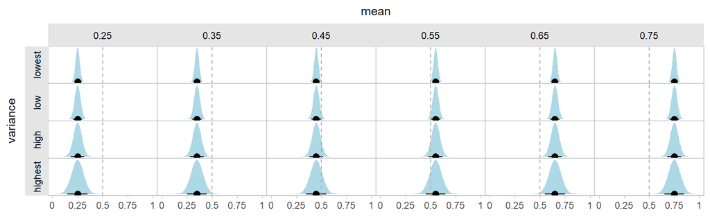

```r
x_breaks = seq(0, 1, by = 1/4)

mean_variance_grid %>%
  ggplot(aes(x = mu, y = 0, xmin = lower, xmax = upper)) +
  geom_ribbon(aes(x = x, ymin = 0, ymax = d), fill = "lightblue", data = unnest) +
  geom_pointrangeh() +
  geom_vline(xintercept = 0.5, linetype = "dashed", color = "gray65") +
  facet_grid(variance ~ mu, switch = "y") +

  scale_y_continuous(breaks = NULL) +
  scale_x_continuous(breaks = x_breaks, labels = x_breaks) +
  ylab("variance") +
  xlab(NULL) +
  panel_border() +
  ggtitle(NULL, subtitle = "mean") +
  theme(
    plot.subtitle = element_text(hjust = 0.5),
    panel.spacing = unit(0, "points")
  )
```

Our goal will be to apply a correction by stuffing these distributions through a model of human probability perception.

## Linear-in-probit model

The linear-in-probit model looks like this:

```r
lp = function(p, alpha = llo_intercept, beta = llo_slope) {
  pnorm(qnorm(p) * beta + alpha)
}
inv_lp = function(p, alpha = llo_intercept, beta = llo_slope) {
  pnorm((qnorm(p) - llo_intercept) / llo_slope)
}
```

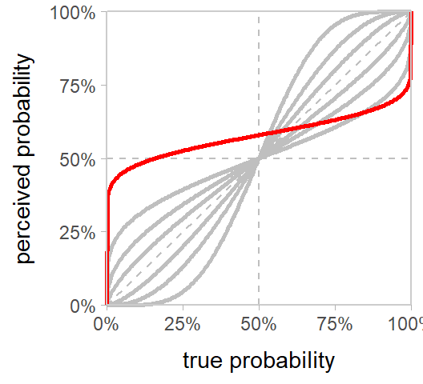

```r
lp_in_prob_space = tibble(
  alpha = c(.2, 0,   0,  0,  0,     0,    0,    0),
  beta  = c(.2, .4, .4, .6, .8,  1/.8, 1/.6, 1/.4),
  curve = interaction(alpha, beta),
  true_p = list(seq(0, 1, length.out = 300))
) %>%
  unnest(true_p) %>%
  mutate(perceived_p = lp(true_p, alpha, beta)) %>%
  ggplot(aes(x = true_p, y = perceived_p, group = curve)) +
  geom_hline(yintercept = .5, linetype = "dashed", color = "gray75") +
  geom_vline(xintercept = .5, linetype = "dashed", color = "gray75") +
  geom_abline(slope = 1, intercept = 0, linetype = "dashed", color = "gray75") +
  geom_line(color = "gray75", size = 1, data = . %>% filter(alpha == 0)) +
  geom_line(color = "red", size = 1, data = . %>% filter(alpha != 0)) +
  coord_cartesian(expand = FALSE, clip = "off") +
  scale_x_continuous(limits = c(0,1), labels = scales::percent) +
  scale_y_continuous(limits = c(0,1), labels = scales::percent) +
  xlab("true probability") +
  ylab("perceived probability")  +
  theme_tidybayes() +
  panel_border()

lp_in_prob_space
```

And in probit-probit space:

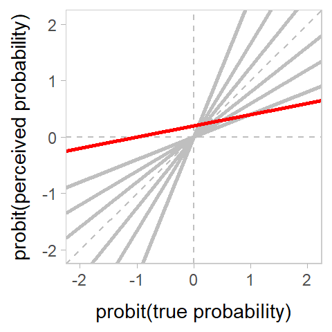

```r
lp_in_probit_space = tibble(
  alpha = c(.2, 0,   0,  0,  0,     0,    0,    0),
  beta  = c(.2, .4, .4, .6, .8,  1/.8, 1/.6, 1/.4),
  curve = interaction(alpha, beta),
) %>%
  ggplot(aes(x = qnorm(true_p), y = qnorm(perceived_p), group = curve)) +
  geom_hline(yintercept = 0, linetype = "dashed", color = "gray75") +
  geom_vline(xintercept = 0, linetype = "dashed", color = "gray75") +
  geom_abline(slope = 1, intercept = 0, linetype = "dashed", color = "gray75") +
  geom_abline(aes(intercept = alpha, slope = beta),
    color = "gray75", size = 1, data = . %>% filter(alpha == 0)) +
  geom_abline(aes(intercept = alpha, slope = beta),
    color = "red", size = 1, data = . %>% filter(alpha != 0)) +
  coord_cartesian(expand = FALSE) +
  xlim(-2.25, 2.25) +
  ylim(-2.25, 2.25) +
  xlab("probit(true probability)") +
  ylab("probit(perceived probability)")  +
  theme_tidybayes() +
  panel_border()

lp_in_probit_space
```

Altogether:

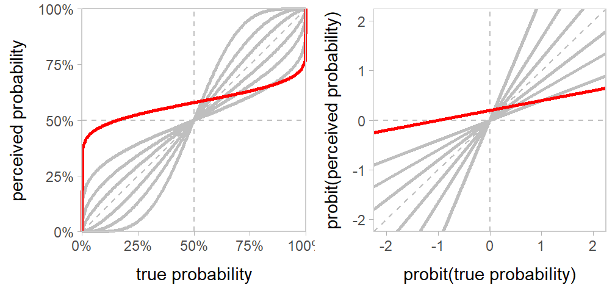

```r
plot_grid(ncol = 2, rel_widths = c(1.05,1),
  lp_in_prob_space,
  lp_in_probit_space
)
```

```r
ggsave("figures/linear-in-probit.pdf", width = 5.25, height = 2.5)
```

## Linear in probit correction derivation

Deriving a linear-in-probit perceptual correction by stuffing a Normal CDF through the linear-in-probit function (also the LLO <-> LPO conversion as a bonus):

$$\begin{align*}
&& \mathrm{logit}(p) &= \frac{p}{1-p} \\
\\
&& \mathrm{llo}(p) &= \mathrm{logit}^{-1}(\alpha' + \beta' \cdot \mathrm{logit}(p)) \\
&& \mathrm{llo}^{-1}(p) &= \mathrm{logit}^{-1}\left(\frac{\mathrm{logit}(p) - \alpha'}{\beta'} \right) \\
\\
&& \mathrm{lpr}(p) &= \Phi\left(\alpha + \beta \cdot \Phi^{-1}(p) \right) \\
&& \mathrm{lpr}^{-1}(p) &= \Phi\left(\frac{\Phi^{-1}(p) - \alpha}{\beta} \right) \\
\\
&& \mathrm{logit}(p) &\approx \Phi^{-1}(p) \cdot 1.6 &\textrm{(Amemiya, 1981)} \\
\implies && \mathrm{llo}(p) &\approx \Phi\left(\frac{\alpha' + \beta' \cdot \Phi^{-1}(p)\cdot 1.6}{1.6}\right) \\
&& &= \Phi\left(\frac{\alpha'}{1.6} + \beta' \cdot \Phi^{-1}(p)\right) \\
\implies && \alpha &\approx \frac{\alpha'}{1.6} \\
&& \beta &\approx \beta' \\
\\
&& X &\sim \mathrm{Normal}(\mu, \sigma)\\
\implies && \mathbb{P}(X \le x) &= \mathrm{F}_\mathrm{Normal}\big(x|\mu,\sigma\big) \\
&& &= \Phi\Big(\frac{x - \mu}{\sigma}\Big) \\
\\
&& {\mathbb{P}(\overset{<}{X}\le x)} &= \mathrm{lpr}^{-1}\left({\mathbb{P}(X \le x)}\right) \\
&& &= \mathrm{lpr}^{-1}\left(\Phi\left(\frac{x - \mu}{\sigma}\right)\right) \\
&& &= \Phi\left(\frac{\frac{x - \mu}{\sigma} - \alpha}{\beta}\right) \\
&& &= \Phi\Big(\frac{x - \mu - \sigma\alpha}{\sigma\beta}\Big) \\
&& &= \mathrm{F}_\mathrm{Normal}\big(x | \mu + \sigma\alpha, \sigma\beta \big) \\
\\
\implies && \overset{<}{X}&\sim \mathrm{Normal}\left(\overset{<}{\mu}, {\overset{<}{\sigma}}\!\;{}^2\right)\\
&& \overset{<}{\mu}&= \mu + \sigma\alpha \\
&& \overset{<}{\sigma}&= \sigma\beta
\end{align*}$$

And for right-tailed probabilities:

$$\begin{align*}
&& {\mathbb{P}(\overset{>}{X}\ge x)} &= \mathrm{lpr}^{-1}\left({\mathbb{P}(X \ge x)}\right) \\
&& \mathbb{P}(-\overset{>}{X}\le -x) &= \mathrm{lpr}^{-1}\left(\mathbb{P}(-X \le -x)\right) \\
&& &= \mathrm{lpr}^{-1}\left(\Phi\left(\frac{-x + \mu}{\sigma}\right)\right) \\
&& &= \Phi\left(\frac{\frac{-x + \mu}{\sigma} - \alpha}{\beta}\right) \\
&& &= \Phi\Big(\frac{-x + \mu - \sigma\alpha}{\sigma\beta}\Big) \\
&& &= \mathrm{F}_\mathrm{Normal}\big(-x | -\mu + \sigma\alpha, \sigma\beta \big) \\
\\
\implies && -\overset{>}{X}&\sim \mathrm{Normal}\left(-\overset{>}{\mu}, {\overset{>}{\sigma}}\!\;{}^2\right)\\
&& \overset{>}{\mu}&= \mu - \sigma\alpha \\
&& \overset{>}{\sigma}&= \sigma\beta \\
\implies && \overset{>}{X}&\sim \mathrm{Normal}\left(\overset{>}{\mu}, {\overset{>}{\sigma}}\!\;{}^2\right)\\
\end{align*}$$

I also thought about keeping sigma fixed and only using a fixed reference point (instead of all points) to do the CDF translation, but it ends up being senseless since it results in a linear scaling all $\mu$ by $\beta$ which would then immediately be undone by any mapping to a color scale. Might be useful for non-color-palette applications though:

$$\begin{align*}
&& \mathbb{P}(X^* \le 0) &= \mathrm{lpr}^{-1}\big(\mathbb{P}(X \le 0)\big) &\textrm{where }\sigma^*=\sigma\\
&& &= \mathrm{lpr}^{-1}\Big(\mathrm{F}_\mathrm{Normal}\Big(\frac{-\mu}{\sigma}\Big)\Big) \\
&& &= \mathrm{F}_\mathrm{Normal}\left(\frac{\frac{-\mu}{\sigma} - \alpha}{\beta}\right) \\
&& &= \mathrm{F}_\mathrm{Normal}\left(\frac{-\frac{\mu + \sigma\alpha}{\beta}}{\sigma}\right) \\
&& \mathrm{F}_\mathrm{Normal}\big(0 | \mu^*, \sigma) &= \mathrm{F}_\mathrm{Normal}\left(0 \middle| \frac{\mu + \sigma\alpha}{\beta}, \sigma \right) \\
\\
\implies && X^* &\sim \mathrm{Normal}(\mu^*, \sigma)\\
&& \mu^* &= \frac{\mu + \sigma\alpha}{\beta}
\end{align*}$$